# CourseAssignment#1

Eric Kruep

Saturday, April 18, 2015

### Loading and preprocessing the data

Step 1: Download data from provided link to local file (https://d396qusza40orc.cloudfront.net/repdata%2Fdata%2Factivity.zip)

Step 2: Load the data from local file into R

```r
data <- read.csv("./data/activity.csv")

summary(data)
```

```
##      steps                date          interval
##  Min.   :  0.00   2012-10-01:  288   Min.   :   0.0
##  1st Qu.:  0.00   2012-10-02:  288   1st Qu.: 588.8
##  Median :  0.00   2012-10-03:  288   Median :1177.5
##  Mean   : 37.38   2012-10-04:  288   Mean   :1177.5
##  3rd Qu.: 12.00   2012-10-05:  288   3rd Qu.:1766.2
##  Max.   :806.00   2012-10-06:  288   Max.   :2355.0
##  NA's   :2304     (Other)   :15840
```

```r
head(data)
```

```
##   steps       date interval
## 1    NA 2012-10-01        0
## 2    NA 2012-10-01        5
## 3    NA 2012-10-01       10
## 4    NA 2012-10-01       15
## 5    NA 2012-10-01       20
## 6    NA 2012-10-01       25
```

```r
str(data)
```

```
## 'data.frame':    17568 obs. of  3 variables:
##  $ steps   : int  NA NA NA NA NA NA NA NA NA NA ...
##  $ date    : Factor w/ 61 levels "2012-10-01","2012-10-02",..: 1 1 1 1 1 1 1 1 1 1 ...
##  $ interval: int  0 5 10 15 20 25 30 35 40 45 ...
```

Step 3: Tidy the data for analysis - Convert the data field to Date class and interval field as factor class

```r
data$date <- as.Date(data$date, format = "%Y-%m-%d")
data$interval <- as.factor(data$interval)
```

### What is mean total number of steps taken per day?

Step 1: Calculate the total number of steps taken per day

```r
totalSteps <- aggregate(steps ~ date, data, sum, na.rm=TRUE)
head(totalSteps)
```

```
##         date steps
## 1 2012-10-02   126
## 2 2012-10-03 11352
## 3 2012-10-04 12116
## 4 2012-10-05 13294
## 5 2012-10-06 15420
## 6 2012-10-07 11015
```

Step 2: Make a histogram of the total number of steps taken each day

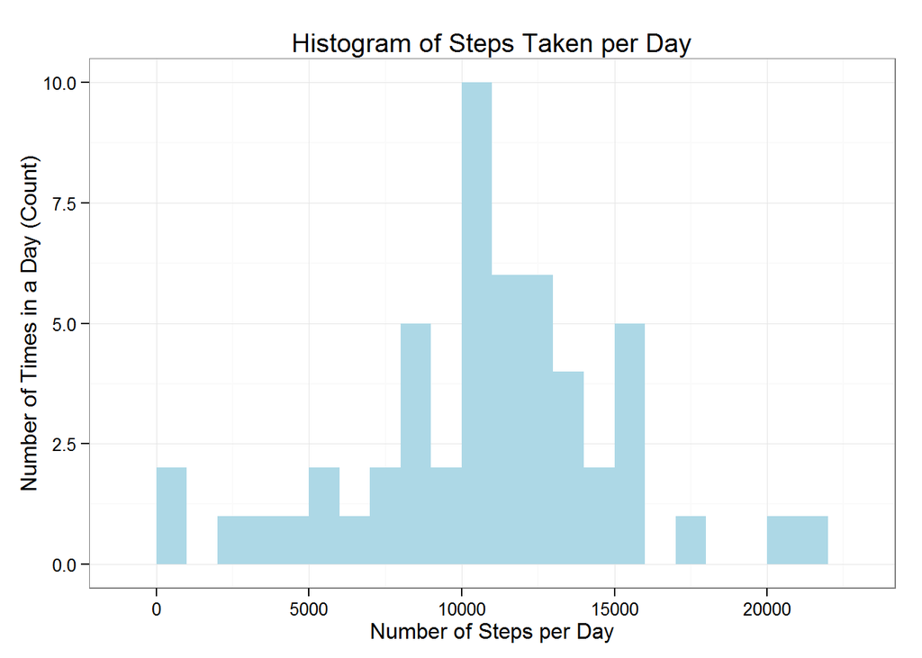

```r
library(ggplot2)

ggplot(totalSteps, aes(x = steps)) +
       geom_histogram(fill = "lightblue", binwidth = 1000) +
        labs(title="Histogram of Steps Taken per Day",
             x = "Number of Steps per Day", y = "Number of Times in a Day (Count)") + theme_bw()
```

```r
meanSteps <- mean(totalSteps$steps, na.rm=TRUE)
medianSteps <- median(totalSteps$steps, na.rm=TRUE)
```

### What is the average daily activity pattern?

Step 1: Make a time series plot (i.e., type = “1”) of the 5-minute interval (x-axis) and the average number of steps taken, averaged across all days (y-axis)

We find the aggregation of steps by intervals of 5-minutes and then convert these intervales to integers. We save them as a data.frame

```r
stepsPerInterval <- aggregate(data$steps,
                                by = list(interval = data$interval),
                                FUN=mean, na.rm=TRUE)

## Convert to integers to aid plotting
stepsPerInterval$interval <- as.integer(levels(stepsPerInterval$interval)[stepsPerInterval$interval])
colnames(stepsPerInterval) <- c("interval", "steps")
```

Then we can plot the data.frame

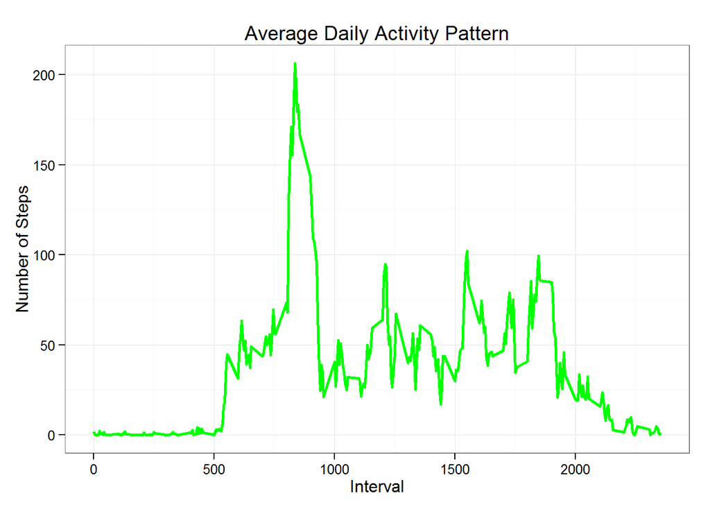

```r
ggplot(stepsPerInterval, aes(x = interval, y = steps)) +
        geom_line(color="green", size=1) +
        labs(title="Average Daily Activity Pattern", x="Interval", y="Number of Steps") +
        theme_bw()
```

Step 2: Which 5-minute interval, on average across all the days in the dataset, contains the maximum number of steps?

```r
maxInterval <- stepsPerInterval[which.max(
        stepsPerInterval$steps),]

maxInterval
```

```
##     interval    steps
## 104      835 206.1698
```

## Imputing missing values

Step 1: Calculate and report the total number of missing values in the dataset (i.e., the total number of rows with NAs)

```r
missingValues <- sum(is.na(data$steps))
```

The total number of missing values is **2304**.

Step 2: Devise a strategy for filling in all of the missing values in the dataset. The strategy chosen here is the following: replace them with the mean value at the same interval across days

```r
naFill <- function(data, pervalue) {
        na_index <- which(is.na(data$steps))
        na_replace <- unlist(lapply(na_index, FUN=function(idx){
                interval = data[idx,]$interval
                pervalue[pervalue$interval == interval,]$steps
        }))
        fill_steps <- data$steps
        fill_steps[na_index] <- na_replace
        fill_steps
}

dataFill <- data.frame(
        steps = naFill(data, stepsPerInterval),
        date = data$date,
        interval = data$interval)
str(dataFill)
```

```
## 'data.frame':    17568 obs. of  3 variables:
##  $ steps   : num  1.717 0.3396 0.1321 0.1509 0.0755 ...
##  $ date    : Date, format: "2012-10-01" "2012-10-01" ...
##  $ interval: Factor w/ 288 levels "0","5","10","15",..: 1 2 3 4 5 6 7 8 9 10 ...
```

Check for any remaining missing values

```r
sum(is.na(dataFill$steps))
```

```
## [1] 0
```

Step 3: Create a new dataset that is equal to the original dataset but with the missing data filled in

```r
fillStepsPerDay <- aggregate(steps ~ date, dataFill, sum)
colnames(fillStepsPerDay) <- c("date","steps")
```

Step 4: Make a histogram of the total number of steps taken each day, calculate and report the mean and median total number of steps taken per day.

Create the histogram with ggplot

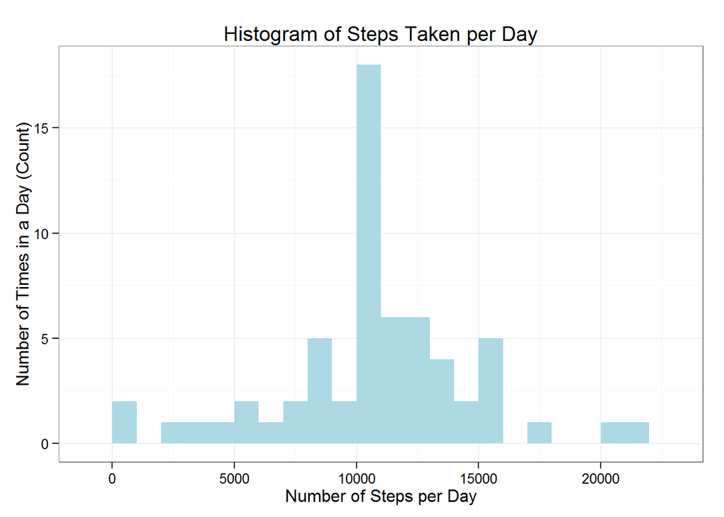

```r
ggplot(fillStepsPerDay, aes(x = steps)) +
       geom_histogram(fill = "lightblue", binwidth = 1000) +
        labs(title="Histogram of Steps Taken per Day",
             x = "Number of Steps per Day", y = "Number of Times in a Day (Count)") + theme_bw()
```

```r
meanFillStepsPerDay <- mean(fillStepsPerDay$steps, na.rm=TRUE)
medianFillStepsPerDay <- median(fillStepsPerDay$steps, na.rm=TRUE)
```

### Are there differences in activity patterns between weekdays and weekends?

Step 1: Use the weekdays() function with the filled-in missing values data to look at differences in between weekdays and weekends

Step 2: Create a new factor variable in the dataset with two levels - “weekday” and “weekend” indicating whether a given date is a weekday or weekend day.

Step 3: Make a panel plot containing a time series plot (i.e. type = “l”) of the 5-minute interval (x-axis) and the average number of steps taken, averaged across all weekday days or weekend days (y-axis). See the README file in the GitHub repository to see an example of what this plot should look like using simulated data.

```r
weekdaysSteps <- function(data) {
    weekdaysSteps <- aggregate(data$steps, by=list(interval = data$interval),
                          FUN=mean, na.rm=TRUE)
    ## Convert to integers for plotting
    weekdaysSteps$interval <-
            as.integer(levels(weekdaysSteps$interval)[weekdaysSteps$interval])
    colnames(weekdaysSteps) <- c("interval", "steps")
    weekdaysSteps
}

dataByWeekdays <- function(data) {
    data$weekday <-
            as.factor(weekdays(data$date)) # weekdays
    weekendData <- subset(data, weekday %in% c("Saturday","Sunday"))
    weekdayData <- subset(data, !weekday %in% c("Saturday","Sunday"))

    weekendSteps <- weekdaysSteps(weekendData)
    weekdaySteps <- weekdaysSteps(weekdayData)

    weekendSteps$dayofweek <- rep("weekend", nrow(weekendSteps))
    weekdaySteps$dayofweek <- rep("weekday", nrow(weekdaySteps))

    dataByWeekdays <- rbind(weekendSteps, weekdaySteps)
    dataByWeekdays$dayofweek <- as.factor(dataByWeekdays$dayofweek)
    dataByWeekdays
}

dataWeekdays <- dataByWeekdays(dataFill)
```

Here is a panel plot comparing the average number of steps taken per 5-minute interval across weekdays and weekends:

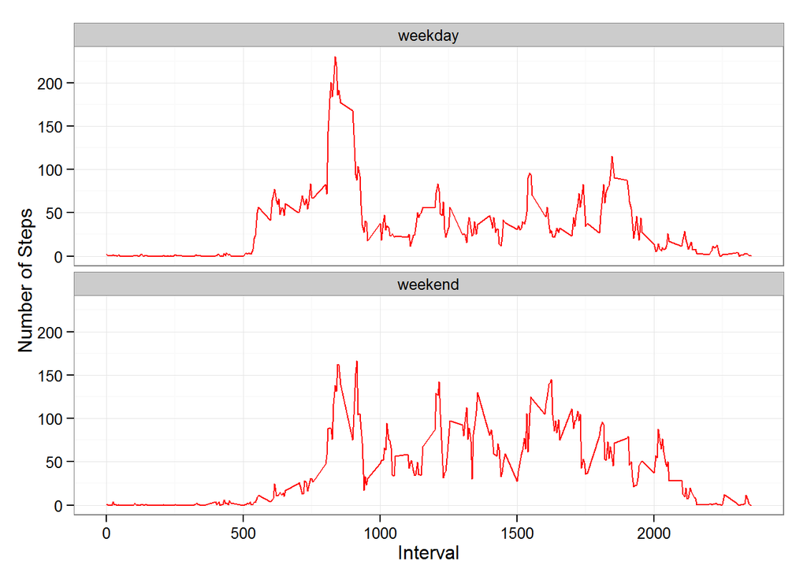

```r
ggplot(dataWeekdays, aes(x = interval, y = steps)) +
        geom_line(color="red") +
        facet_wrap(~ dayofweek, nrow=2, ncol=1) +
        labs(x="Interval", y="Number of Steps") +
        theme_bw()
```

**CONCLUSION:** Activity on the weekends appears to be more consistently higher than during the weekdays.